# STAT 685 - Project in Statistics

Ken Marciel

2/7/2022

# Predicting the Incidence of Postoperative Nausea and Vomiting (PONV)

The incidence of post-operative nausea and vomiting (PONV) is generally in the range of 20-40% (Apfel *et al*). This condition has negative effects on the health and well-being of patients, and is financially costly to healthcare providers. The tradeoff is that preventive therapy has negative side effects and financial costs. So, the challenge is to develop a scoring system that most accurately recommends prophylaxis for the patients at high risk of PONV. In other words, a predictive model that is neither to conservative nor too liberal in determining which patients should be prescribed prophylaxis. This balancing act has been described in the medical literature as the prevent-or-cure dilemma.

There are several well-documented models for predicting PONV, to help guide prudent administration of anti-emetic prophylaxis. These models are typically developed using logistic regression and stepwise backward elimination for variable selection. The most common measures of validity are discrimination and calibration. The most common measure of discriminating power is AUC, the area under the receiver operating characteristic curve (ROC). Calibration is most commonly assessed using the slope and squared correlation ($R^2$) for the line in a calibration plot. In the literature, AUC values range from 0.61 to 0.785 (Apfel *et al*, Sinclair *et al*), calibration slopes range from 0.3 to 1.71 (Apfel *et al*, Eberhart *et al*), and squared correlation ranges from 0.763 to 0.99 (Apfel *et al*).

This investigation analyzed a data set of 461 patients from anesthesiologist Jelena Velickovic, MD, in Belgrade, Serbia. The purpose was to develop a predictive model for PONV with performance comparable to or better than models previously published in the literature.

## Methods

Data analysis was performed using the R statistical computing software through the R Markdown interface, with the following additional packages installed to R.

## Packages

```r
library(dplyr) # rename variables
library(alr4) # marginal model plots
library(leaps) # regression subset plots
library(car) # regression subset plots
library(rms) # logistic regression
library(pROC) # ROC curve
library(caret) # data splitting, resampling
```

## Data set

The raw data set has 916 rows and 26 columns. None of the rows have missing values. After removing the 93 duplicates, the cleaned data set has 823 rows and 26 columns.

## Sample size

After removing the 362 records of patients who received prophylaxis, the data set now has 461 rows and 26 columns.

## Variables in data set

Next, we will make sure that the original 26 variables are properly encoded for data analysis.

The 26 variables from the original data set consist of the ID variable, 9 response variables, and 16 predictor variables.

## Variables considered for analysis of PONV incidence within 24 hours

Response variable selected:

$Y$ = PONV0to24 (binary) = incidence of PONV within 24 hours of operation

For the purpose of developing a predictive model for PONV, we exclude the eight predictor variables corresponding to anesthetic and postoperative patient risk factors. In the full model, we consider the remaining eight predictor variables corresponding to the preoperative patient risk factors:

$x_{1}$ = Age (integer)  
$x_{2}$ = Gender (binary)  
$x_{3}$ … $x_{27}$ = Diagnosis (categorical with 26 levels)  
$x_{28}$ … $x_{34}$ = Surgery (categorical with 8 levels)  
$x_{35}$ = BMI (real)  
$x_{36}$ = Nonsmoker (binary)  
$x_{37}$ = Kinetosis history (binary)  
$x_{38}$ = PONV history (binary)

The model includes 25 dummy variables for the 26 levels of *Diagnosis*, and 7 dummy variables for the 8 levels of *Surgery*. This is a total of 38 variables, when the factors with more than two levels are taken into full account.

The 10 variables in the data set for the full model consist of the ID variable, the response variable, and 8 predictor variables. The observed incidence of PONV for this data set is 0.37.

## Full model for logistic regression

We begin by considering the following generalized linear model for the binary response variable:

$Y=g(\beta_{0}+\beta_{1}x_{1}+\beta_{2}x_{2}+\beta_{3}x_{3}+...+\beta_{27}x_{27}+\beta_{28}x_{28}+...+\beta_{34}x_{34}+\beta_{35}x_{35}+\beta_{36}x_{36}+\beta_{37}x_{37}+\beta_{38}x_{38}+e)$

where *e* ~ iid $N(0,1)$.

To model the binary response variable through a generalized linear model, we use the log odds ratio (logit) as the link function as follows:

$g^{-1}(Y)=\log(\frac{\theta(Y)}{1-\theta(Y)})=\beta_{0}+\beta_{1}x_{1}+\beta_{2}x_{2}+\beta_{3}x_{3}+...+\beta_{27}x_{27}+\beta_{28}x_{28}+...+\beta_{34}x_{34}+\beta_{35}x_{35}+\beta_{36}x_{36}+\beta_{37}x_{37}+\beta_{38}x_{38}+e$

$\theta$ is the parameter of the binomial distribution, which is related to a transformation of the logit as follows:

$\theta(Y)=\frac{\exp(Y)}{1+\exp(Y)}=\frac{1}{1+{\exp(-Y)}}$

For this analysis, our $\theta$ of interest is the proportion of patients diagnosed with PONV within the 24 hours following surgery.

The logistic regression model is fitted using the generalized linear method of least squares:

```
##
## Call:
## glm(formula = PONV0to24 ~ Age + Gender + Diagnosis + Surgery +
##     BMI + Nonsmoker + KinetosisHistory + PONVhistory, family = binomial,
##     data = ponv)
##
## Deviance Residuals:
##     Min       1Q   Median       3Q      Max
## -1.7753  -0.9663  -0.5579   1.1567   2.3369
##
## Coefficients:
##                     Estimate Std. Error z value Pr(>|z|)
## (Intercept)       -1.817e+01  1.171e+03  -0.016   0.9876
## Age               -3.662e-03  8.834e-03  -0.415   0.6785
## Gender1            8.547e-01  3.217e-01   2.656   0.0079 **
## Diagnosis1         9.179e-01  6.314e-01   1.454   0.1460
## Diagnosis2         1.079e+00  5.780e-01   1.868   0.0618 .
## Diagnosis3         1.081e+00  7.968e-01   1.357   0.1748
## Diagnosis4         1.108e+00  6.124e-01   1.809   0.0705 .
## Diagnosis5        -1.851e-01  8.955e-01  -0.207   0.8362
## Diagnosis6         1.136e+00  9.282e-01   1.224   0.2211
## Diagnosis7         1.493e+00  1.674e+00   0.892   0.3726
## Diagnosis8        -7.698e-01  1.217e+00  -0.632   0.5272
## Diagnosis9        -6.555e-01  1.450e+00  -0.452   0.6513
## Diagnosis10        1.634e+00  2.022e+00   0.808   0.4191
## Diagnosis11       -1.439e+01  2.400e+03  -0.006   0.9952
## Diagnosis12       -1.392e+01  1.696e+03  -0.008   0.9935
## Diagnosis13       -3.879e-02  8.915e-01  -0.044   0.9653
## Diagnosis14        1.801e+01  1.223e+03   0.015   0.9883
## Diagnosis15        6.021e-01  8.127e-01   0.741   0.4587
## Diagnosis16        7.782e-01  9.200e-01   0.846   0.3976
## Diagnosis17       -1.397e+01  1.340e+03  -0.010   0.9917
## Diagnosis18        1.664e+01  2.400e+03   0.007   0.9945
## Diagnosis19        5.787e-01  9.616e-01   0.602   0.5473
## Diagnosis20        8.271e-01  1.384e+00   0.598   0.5500
## Diagnosis23        1.838e+01  2.400e+03   0.008   0.9939
## Diagnosis24       -1.458e+01  2.400e+03  -0.006   0.9952
## Diagnosis25        1.896e+01  2.400e+03   0.008   0.9937
## Surgery1           1.530e+01  1.171e+03   0.013   0.9896
## Surgery2           1.522e+01  1.171e+03   0.013   0.9896
## Surgery3           3.240e+01  2.670e+03   0.012   0.9903
## Surgery4           1.548e+01  1.171e+03   0.013   0.9894
## Surgery5          -2.295e+00  1.693e+03  -0.001   0.9989
## Surgery7           1.426e+01  1.171e+03   0.012   0.9903
## BMI                2.241e-02  2.415e-02   0.928   0.3536
## Nonsmoker1         5.353e-01  2.454e-01   2.181   0.0292 *
## KinetosisHistory1  8.598e-02  4.972e-01   0.173   0.8627
## PONVhistory1       1.432e+00  3.414e-01   4.194 2.74e-05 ***
## ---
## Signif. codes:  0 '***' 0.001 '**' 0.01 '*' 0.05 '.' 0.1 ' ' 1
##
## (Dispersion parameter for binomial family taken to be 1)
##
##     Null deviance: 609.06  on 460  degrees of freedom
## Residual deviance: 522.95  on 425  degrees of freedom
## AIC: 594.95
##
## Number of Fisher Scoring iterations: 15
```

Three of the predictors in the full model have estimated coefficients that are statistically significant. In descending order of significance, these are PONV history, gender, and nonsmoker.

### Plots of standardized deviance residuals

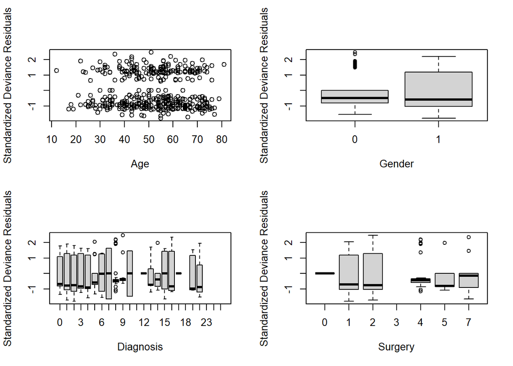

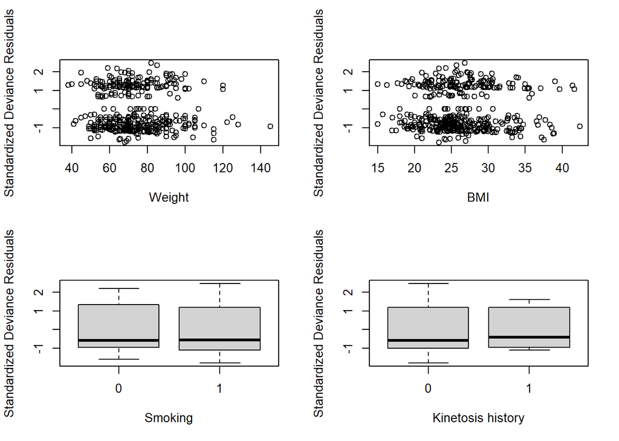

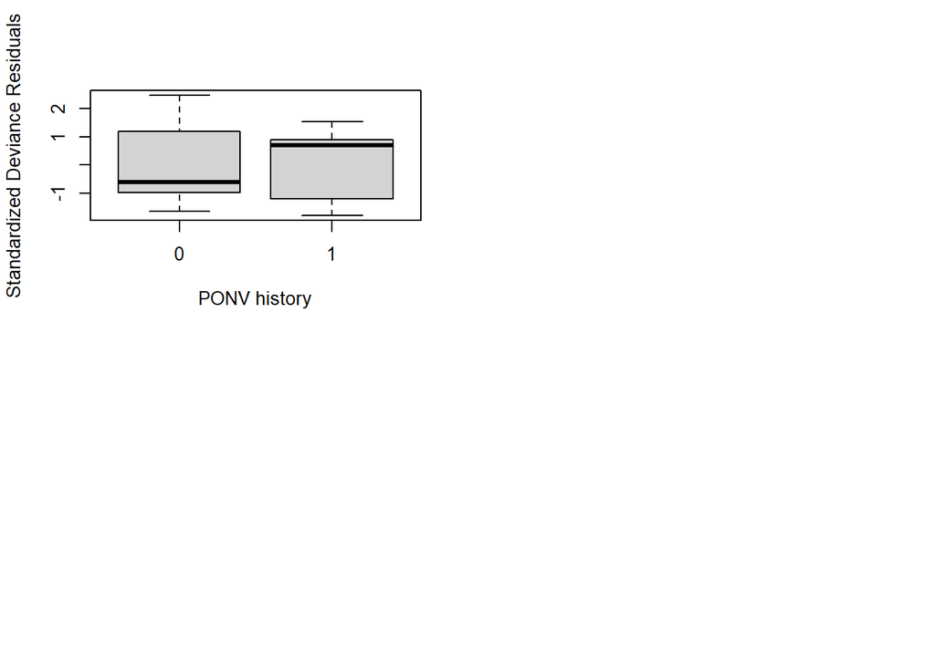

Skewness is present in all of the predictors, most of which are right-skewed. This suggests that the log odds may depend on each skewed predictor through both a linear function and a log transformation. However, residual plots are difficult to interpret for binary data, so we will examine marginal model plots instead.

### Marginal model plots for the continuous predictors

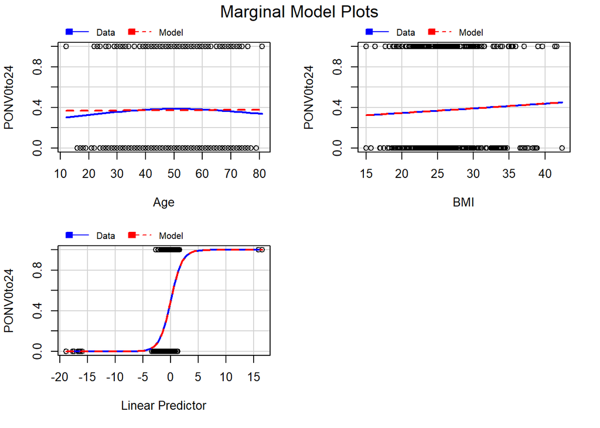

There is reasonable agreement between the two fits in each of the marginal model plots for BMI and the linear predictor. Due to the lack of fit for Age, and the presence of parabolic curvature for the observed response, one possible approach is to consider adding a quadratic term for Age.

$g^{-1}(Y)=\log(\frac{\theta(Y)}{1-\theta(Y)})=\beta_{0}+\beta_{1}x_{1}+\beta_{2}x_{2}^2+\beta_{3}x_{3}+\beta_{4}x_{4}+...+\beta_{28}x_{28}+\beta_{29}x_{29}+...+\beta_{35}x_{35}+\beta_{36}x_{36}+\beta_{37}x_{37}+\beta_{38}x_{38}+\beta_{39}x_{39}+e$

```
##
## Call:
## glm(formula = PONV0to24 ~ Age + I(Age^2) + Gender + Diagnosis +
##     Surgery + BMI + Nonsmoker + KinetosisHistory + PONVhistory,
##     family = binomial, data = ponv)
##
## Deviance Residuals:
##     Min       1Q   Median       3Q      Max
## -1.8339  -0.9581  -0.5420   1.1239   2.3112
##
## Coefficients:
##                     Estimate Std. Error z value Pr(>|z|)
## (Intercept)       -1.994e+01  1.168e+03  -0.017   0.9864
## Age                7.853e-02  5.507e-02   1.426   0.1539
## I(Age^2)          -8.170e-04  5.392e-04  -1.515   0.1298
## Gender1            8.152e-01  3.223e-01   2.529   0.0114 *
## Diagnosis1         8.950e-01  6.322e-01   1.416   0.1569
## Diagnosis2         1.077e+00  5.786e-01   1.862   0.0627 .
## Diagnosis3         1.053e+00  7.991e-01   1.318   0.1875
## Diagnosis4         1.189e+00  6.157e-01   1.932   0.0534 .
## Diagnosis5        -1.127e-01  8.928e-01  -0.126   0.8996
## Diagnosis6         1.204e+00  9.253e-01   1.301   0.1933
## Diagnosis7         1.488e+00  1.688e+00   0.882   0.3780
## Diagnosis8        -8.362e-01  1.218e+00  -0.687   0.4924
## Diagnosis9        -8.259e-01  1.453e+00  -0.568   0.5697
## Diagnosis10        2.031e+00  2.040e+00   0.996   0.3193
## Diagnosis11       -1.348e+01  2.400e+03  -0.006   0.9955
## Diagnosis12       -1.376e+01  1.696e+03  -0.008   0.9935
## Diagnosis13       -4.460e-02  8.909e-01  -0.050   0.9601
## Diagnosis14        1.822e+01  1.220e+03   0.015   0.9881
## Diagnosis15        5.787e-01  8.139e-01   0.711   0.4771
## Diagnosis16        9.297e-01  9.279e-01   1.002   0.3164
## Diagnosis17       -1.398e+01  1.336e+03  -0.010   0.9916
## Diagnosis18        1.680e+01  2.400e+03   0.007   0.9944
## Diagnosis19        7.261e-01  9.649e-01   0.753   0.4517
## Diagnosis20        7.744e-01  1.380e+00   0.561   0.5746
## Diagnosis23        1.851e+01  2.400e+03   0.008   0.9938
## Diagnosis24       -1.479e+01  2.400e+03  -0.006   0.9951
## Diagnosis25        1.888e+01  2.400e+03   0.008   0.9937
## Surgery1           1.535e+01  1.168e+03   0.013   0.9895
## Surgery2           1.532e+01  1.168e+03   0.013   0.9895
## Surgery3           3.246e+01  2.669e+03   0.012   0.9903
## Surgery4           1.563e+01  1.168e+03   0.013   0.9893
## Surgery5          -2.504e+00  1.689e+03  -0.001   0.9988
## Surgery7           1.415e+01  1.168e+03   0.012   0.9903
## BMI                1.406e-02  2.485e-02   0.566   0.5716
## Nonsmoker1         5.910e-01  2.495e-01   2.368   0.0179 *
## KinetosisHistory1  1.241e-02  4.976e-01   0.025   0.9801
## PONVhistory1       1.409e+00  3.430e-01   4.106 4.02e-05 ***
## ---
## Signif. codes:  0 '***' 0.001 '**' 0.01 '*' 0.05 '.' 0.1 ' ' 1
##
## (Dispersion parameter for binomial family taken to be 1)
##
##     Null deviance: 609.06  on 460  degrees of freedom
## Residual deviance: 520.59  on 424  degrees of freedom
## AIC: 594.59
##
## Number of Fisher Scoring iterations: 15
```

After adding a squared term for age to the full model, three of the predictors have estimated coefficients that are statistically significant. In descending order of significance, these are PONV history, gender, and nonsmoker. This is the same result obtained without the squared term for age.

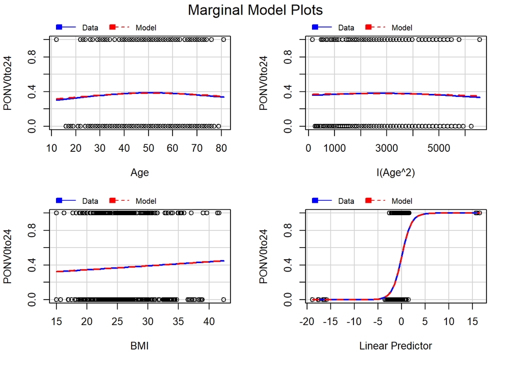

After adding the quadratic term for age, there is reasonable agreement between the two fits (observed and predicted) in each of the marginal model plots for $Age$, $Age^2$, $BMI$, and the linear predictor. This indicates that the current model is an adequate fit for the data.

### Leverage values and standardized deviance residuals

As a final validity check, we examine leverage values and standardized deviance residuals.

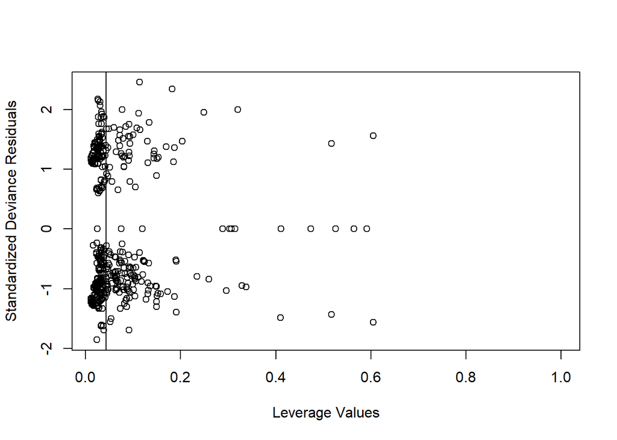

```
## integer(0)
```

A plot of leverage values and standardized deviance residuals reveals that none of the leverage points exceed 2.5 standard deviations. Six of the points exceed two standard deviations and should be investigated. However, since these points comprise only 1% of the 461 values in the data set, we will continue with the assumption that the current model is an adequate fit for the data. Therefore, we next proceed to variable selection.

## Variable selection using all possible subsets

### Plots of $R^2_{adj}$ against subset size for the best subset of each size

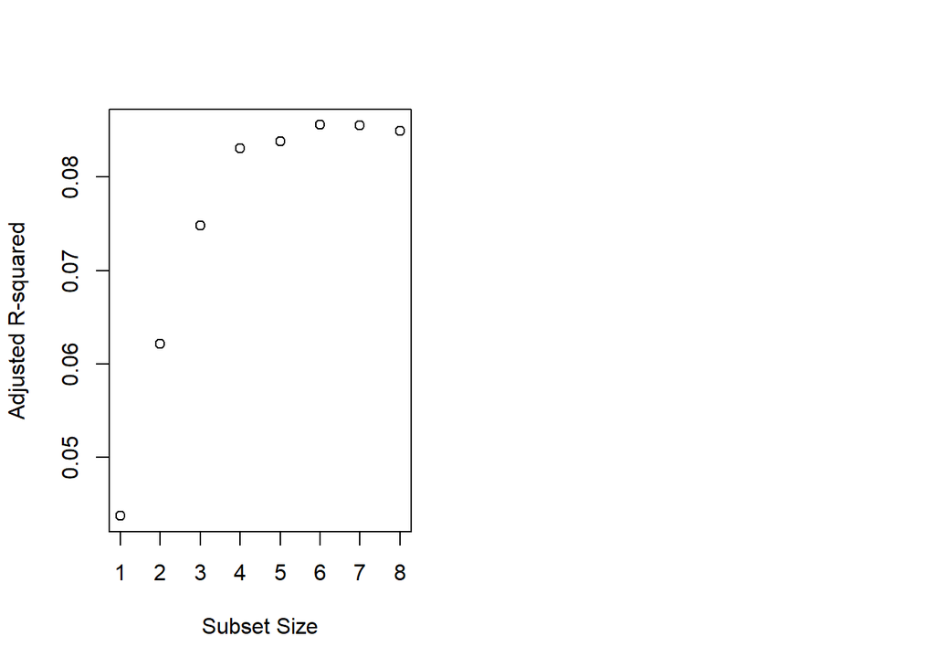

The plot of adjusted $R^2$ values shows the best predictor subsets to be as follows:

1 predictor: PONVhistory  
2 predictors: PONVhistory, Surgery  
3 predictors: PONVhistory, Surgery, Gender  
4 predictors: PONVhistory, Surgery, Gender, Nonsmoker  
5 predictors: PONVhistory, Surgery, Gender, Nonsmoker, Age$^2$  
6 predictors: PONVhistory, Surgery, Gender, Nonsmoker, Age$^2$, BMI  
7 predictors: PONVhistory, Surgery, Gender, Nonsmoker, Age$^2$, BMI, Age  
8 predictors: PONVhistory, Surgery, Gender, Nonsmoker, Age$^2$, BMI, Age, KinetosisHistory

Viewing the results of the adjusted $R^2$ plot another way, the number of models that include each variable is as follows:

8 models: PONVhist  
7 models: Surgery  
6 models: Gender  
5 models: Nonsmoker  
4 models: Age$^2$  
3 models: BMI  
2 models: Age  
1 model: KinetosisHist

### Values of $R^2_{adj}$, AIC, AIC$_{C}$, and BIC for the best subset of each size

The predictor with the smallest *p*-value for its estimated coefficient is added to each subset to obtain the next subset.

```r
# Subset size = 1
om1 <- glm(PONV0to24 ~ PONVhistory, family = binomial, data = ponv)
# Subset size = 2
om2 <- glm(PONV0to24 ~ PONVhistory + Surgery, family = binomial, data = ponv)
# Subset size = 3
om3 <- glm(PONV0to24 ~ PONVhistory + Surgery + Gender, family = binomial,
          data = ponv)
# Subset size = 4
om4 <- glm(PONV0to24 ~ PONVhistory + Surgery + Gender + Nonsmoker,
          family = binomial, data = ponv)
# Subset size = 5
om5 <- glm(PONV0to24 ~ PONVhistory + Surgery + Gender + Nonsmoker + I(Age^2),
          family = binomial, data = ponv)
# Subset size = 6
om6 <- glm(PONV0to24 ~ PONVhistory + Surgery + Gender + Nonsmoker + I(Age^2)
           + BMI, family = binomial, data = ponv)
# Subset size = 7
om7 <- glm(PONV0to24 ~ PONVhistory + Surgery + Gender + Nonsmoker + I(Age^2)
           + BMI + Age, family = binomial, data = ponv)
# Subset size = 8
om8 <- glm(PONV0to24 ~ PONVhistory + Surgery + Gender + Nonsmoker + I(Age^2)
           + BMI + Age + KinetosisHistory, family = binomial, data = ponv)
# Subset size = 9
om9 <- glmFit2
```

### Calculate AIC

```r
extractAIC(om1, k = 2)
```

```
## [1]   2.000 592.694
```

```r
extractAIC(om2, k = 2)
```

```
## [1]   8.0000 581.4326
```

```r
extractAIC(om3, k = 2)
```

```
## [1]   9.0000 575.9521
```

```r
extractAIC(om4, k = 2)
```

```
## [1]  10.000 574.025
```

```r
extractAIC(om5, k = 2)
```

```
## [1]  11.0000 575.1732
```

```r
extractAIC(om6, k = 2)
```

```
## [1]  12.0000 575.3149
```

```r
extractAIC(om7, k = 2)
```

```
## [1]  13.0000 575.9791
```

```r
extractAIC(om8, k = 2)
```

```
## [1]  14.0000 577.3641
```

```r
extractAIC(om9, k = 2)
```

```
## [1]  37.0000 594.5913
```

The minimum value of AIC corresponds to the predictor subset of size four: PONVhistory, Surgery, Gender, and Nonsmoker.

### Calculate AIC$_{C}$

```r
npar.1 <- length(om1$coefficients) + 1
npar.2 <- length(om2$coefficients) + 1
npar.3 <- length(om3$coefficients) + 1
npar.4 <- length(om4$coefficients) + 1
npar.5 <- length(om5$coefficients) + 1
npar.6 <- length(om6$coefficients) + 1
npar.7 <- length(om7$coefficients) + 1
npar.8 <- length(om8$coefficients) + 1
npar.9 <- length(om9$coefficients) + 1

extractAIC(om1, k = 2) + 2 * npar.1 * (npar.1 + 1) / (n - npar.1 - 1)
```

```
## [1]   2.052516 592.746551
```

```r
extractAIC(om2, k = 2) + 2 * npar.2 * (npar.2 + 1) / (n - npar.2 - 1)
```

```
## [1]   8.399113 581.831722
```

```r
extractAIC(om3, k = 2) + 2 * npar.3 * (npar.3 + 1) / (n - npar.3 - 1)
```

```
## [1]   9.488889 576.440946
```

```r
extractAIC(om4, k = 2) + 2 * npar.4 * (npar.4 + 1) / (n - npar.4 - 1)
```

```
## [1]  10.58797 574.61297
```

```r
extractAIC(om5, k = 2) + 2 * npar.5 * (npar.5 + 1) / (n - npar.5 - 1)
```

```
## [1]  11.69643 575.86968
```

```r
extractAIC(om6, k = 2) + 2 * npar.6 * (npar.6 + 1) / (n - npar.6 - 1)
```

```
## [1]  12.81432 576.12925
```

```r
extractAIC(om7, k = 2) + 2 * npar.7 * (npar.7 + 1) / (n - npar.7 - 1)
```

```
## [1]  13.9417 576.9208
```

```r
extractAIC(om8, k = 2) + 2 * npar.8 * (npar.8 + 1) / (n - npar.8 - 1)
```

```
## [1]  15.07865 578.44275
```

```r
extractAIC(om9, k = 2) + 2 * npar.9 * (npar.9 + 1) / (n - npar.9 - 1)
```

```
## [1]  44.0237 601.6150
```

The minimum value of AIC$_{C}$ also corresponds to the predictor subset of size four: PONVhistory, Surgery, Gender, and Nonsmoker.

### Calculate BIC

```r
extractAIC(om1, k = log(n))
```

```
## [1]   2.0000 600.9608
```

```r
extractAIC(om2, k = log(n))
```

```
## [1]   8.0000 614.4998
```

```r
extractAIC(om3, k = log(n))
```

```
## [1]   9.0000 613.1526
```

```r
extractAIC(om4, k = log(n))
```

```
## [1]  10.000 615.359
```

```r
extractAIC(om5, k = log(n))
```

```
## [1]  11.0000 620.6406
```

```r
extractAIC(om6, k = log(n))
```

```
## [1]  12.0000 624.9157
```

```r
extractAIC(om7, k = log(n))
```

```
## [1]  13.0000 629.7133
```

```r
extractAIC(om8, k = log(n))
```

```
## [1]  14.0000 635.2317
```

```r
extractAIC(om9, k = log(n))
```

```
## [1]  37.000 747.527
```

### Parsimonious model selection

$Y=g(\beta_{0}+\beta_{1}PONVhistory+\beta_{2}Gender+\beta_{3}Nonsmoker+\beta_{4}Surgery+e)$

where *e* ~ iid $N(0,1)$.

As before, we use the logit function to model the binary response variable:

$g^{-1}(Y)=\log(\frac{\theta(Y)}{1-\theta(Y)})=\beta_{0}+\beta_{1}PONVhist+\beta_{2}Gender+\beta_{3}Nonsmoker+\beta_{4}Surgery+e$

where $\theta(Y)=\frac{\exp(Y)}{1+\exp(Y)}=\frac{1}{1+{\exp(-Y)}}$

```
##
## Call:
## glm(formula = PONV0to24 ~ PONVhistory + Gender + Nonsmoker +
##     Surgery, family = binomial, data = ponv)
##
## Deviance Residuals:
##     Min       1Q   Median       3Q      Max
## -1.6459  -1.0281  -0.6627   1.2687   2.1106
##
## Coefficients:
##               Estimate Std. Error z value Pr(>|z|)
## (Intercept)   -16.3253   727.6988  -0.022  0.98210
## PONVhistory1    1.2680     0.3185   3.981 6.85e-05 ***
## Gender1         0.7592     0.2880   2.637  0.00838 **
## Nonsmoker1      0.4329     0.2205   1.963  0.04960 *
## Surgery1       14.9211   727.6988   0.021  0.98364
## Surgery2       14.7712   727.6988   0.020  0.98381
## Surgery3       30.6992  1627.1839   0.019  0.98495
## Surgery4       13.4529   727.6989   0.018  0.98525
## Surgery5       14.0466   727.6997   0.019  0.98460
## Surgery7       14.3985   727.6990   0.020  0.98421
## ---
## Signif. codes:  0 '***' 0.001 '**' 0.01 '*' 0.05 '.' 0.1 ' ' 1
##
## (Dispersion parameter for binomial family taken to be 1)
##
##     Null deviance: 609.06  on 460  degrees of freedom
## Residual deviance: 554.02  on 451  degrees of freedom
## AIC: 574.02
##
## Number of Fisher Scoring iterations: 14
```

```
## Logistic Regression Model
##
##  lrm(formula = PONV0to24 ~ PONVhistory + Gender + Nonsmoker +
##      Surgery, data = ponv)
##
##                          Model Likelihood    Discrimination    Rank Discrim.
##                                Ratio Test           Indexes          Indexes
##  Obs            461    LR chi2      55.03    R2       0.153    C       0.681
##   0             289    d.f.             9    g        0.975    Dxy     0.363
##   1             172    Pr(> chi2) <0.0001    gr       2.652    gamma   0.423
##  max |deriv| 0.0008                          gp       0.172    tau-a   0.170
##                                              Brier    0.208
##
##                Coef    S.E.    Wald Z Pr(>|Z|)
##  Intercept     -9.0549 31.6581 -0.29  0.7749
##  PONVhistory=1  1.2680  0.3185  3.98  <0.0001
##  Gender=1       0.7592  0.2880  2.64  0.0084
##  Nonsmoker=1    0.4329  0.2205  1.96  0.0496
##  Surgery=1      7.6508 31.6574  0.24  0.8090
##  Surgery=2      7.5008 31.6581  0.24  0.8127
##  Surgery=3     16.1977 71.9096  0.23  0.8218
##  Surgery=4      6.1826 31.6600  0.20  0.8452
##  Surgery=5      6.7762 31.6771  0.21  0.8306
##  Surgery=7      7.1281 31.6629  0.23  0.8219
##
```

The chosen model has three estimated coefficients that are statistically significant, which are the same three that are statistically significant in the full model. In descending order of significance, these are PONVhistory, Gender, and Nonsmoker. The fourth predictor in the model is Surgery, but none of the estimated coefficients for this factor predictor variable are statistically significant.

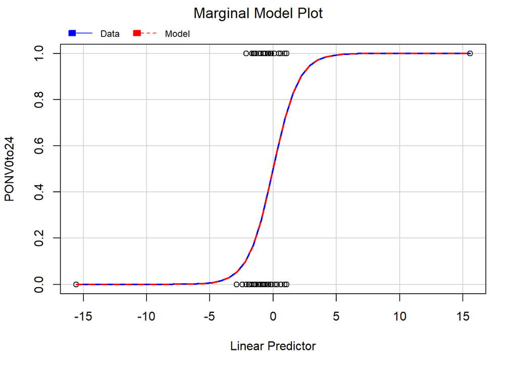

Since the chosen model has only factor predictor variables, a marginal model plot could only be obtained for the linear fit. There is reasonable agreement between the two fits (actual and predicted) in the marginal model plot for the linear fit. This indicates that the model is an adequate fit for the data.

As a final validity check, we next look at leverage values versus standardized deviance residuals.

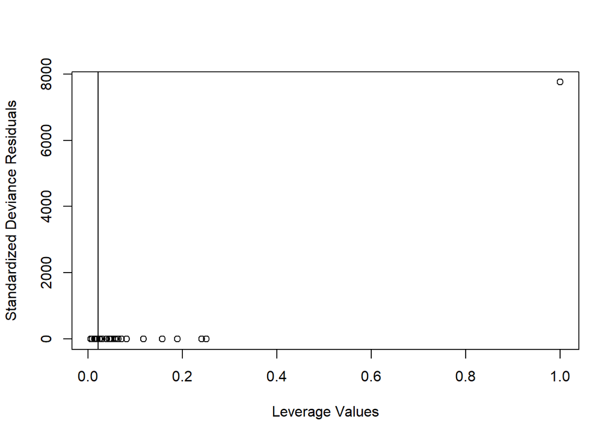

```
## integer(0)
```

The plot of leverage values and standardized deviance residuals consists of a single extreme leverage point, while the remaining points that are all clustered closer to a standard deviation of zero. Recall that none of the coefficients for Surgery were statistically significant. Furthermore, all have high standard errors, with one being more than double the value of the others. Finally, the predictor subsets of three and four have comparable $R^2$. So we will next remove the Surgery variable to give us the predictor subset of three as our parsimonious model:

$Y=g(\beta_{0}+\beta_{1}PONVhistory+\beta_{2}Gender+\beta_{3}Nonsmoker+e)$

where *e* ~ iid $N(0,1)$.

As before, we use the logit function to model the binary response variable:

$g^{-1}(Y)=\log(\frac{\theta(Y)}{1-\theta(Y)})=\beta_{0}+\beta_{1}PONVhist+\beta_{2}Gender+\beta_{3}Nonsmoker+e$

where $\theta(Y)=\frac{\exp(Y)}{1+\exp(Y)}=\frac{1}{1+{\exp(-Y)}}$

```
##
## Call:
## glm(formula = PONV0to24 ~ PONVhistory + Gender + Nonsmoker, family = binomial,
##     data = ponv)
##
## Deviance Residuals:
##    Min      1Q  Median      3Q     Max
## -1.588  -1.023  -0.721   1.340   1.929
##
## Coefficients:
##              Estimate Std. Error z value Pr(>|z|)
## (Intercept)   -1.6911     0.3027  -5.587 2.32e-08 ***
## PONVhistory1   1.3029     0.3132   4.160 3.19e-05 ***
## Gender1        0.8401     0.2803   2.997  0.00273 **
## Nonsmoker1     0.4766     0.2159   2.208  0.02724 *
## ---
## Signif. codes:  0 '***' 0.001 '**' 0.01 '*' 0.05 '.' 0.1 ' ' 1
##
## (Dispersion parameter for binomial family taken to be 1)
##
##     Null deviance: 609.06  on 460  degrees of freedom
## Residual deviance: 573.95  on 457  degrees of freedom
## AIC: 581.95
##
## Number of Fisher Scoring iterations: 4
```

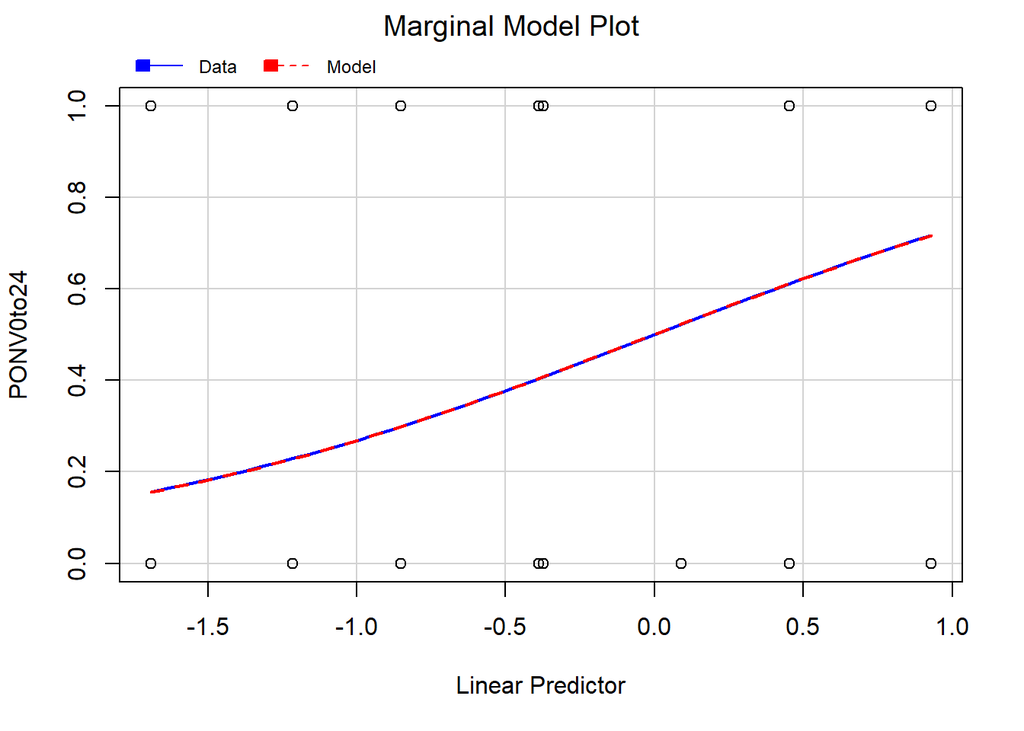

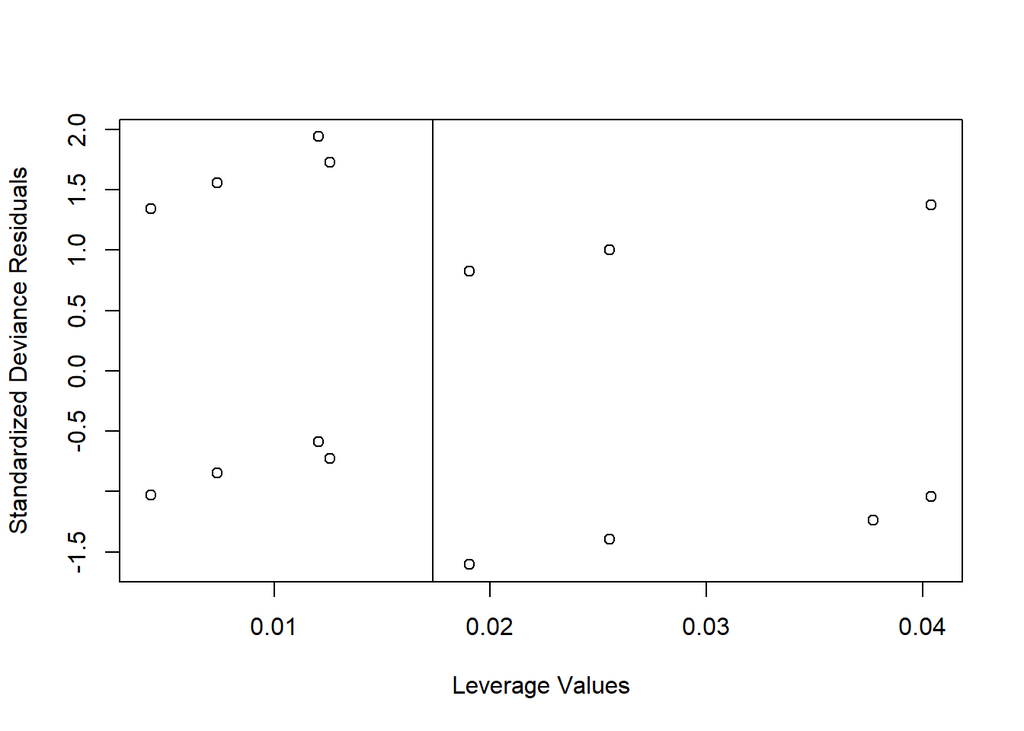

```
## integer(0)
```

In the current model, the intercept and all three predictors are statistically significant. The marginal model plot shows reasonable agreement between the two fits (actual and predicted) for the linear fit. This indicates that the model is an adequate fit for the data. The plot of leverage values and standardized deviance residuals consists of points that are all within two standard deviations, which means there are no bad leverage points.

We next proceed to assess the predictive ability of this model.

```
## Confusion Matrix and Statistics
##
##           Reference
## Prediction   0   1
##          0 272 138
##          1  17  34
##
##                Accuracy : 0.6638
##                  95% CI : (0.6186, 0.7068)
##     No Information Rate : 0.6269
##     P-Value [Acc > NIR] : 0.05527
##
##                   Kappa : 0.1619
##
##  Mcnemar's Test P-Value : < 2e-16
##
##             Sensitivity : 0.9412
##             Specificity : 0.1977
##          Pos Pred Value : 0.6634
##          Neg Pred Value : 0.6667
##              Prevalence : 0.6269
##          Detection Rate : 0.5900
##    Detection Prevalence : 0.8894
##       Balanced Accuracy : 0.5694
##
##        'Positive' Class : 0
##
```

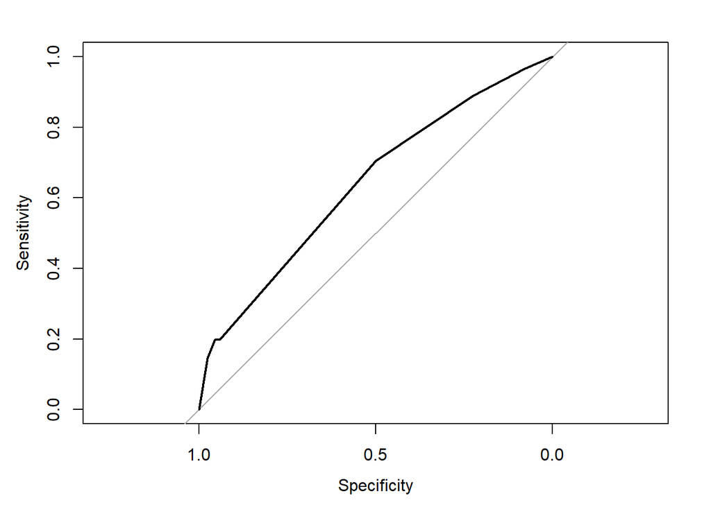

```
##
## Call:
## roc.default(response = PONV0to24, predictor = glmFit4$fitted.values,     plot = TRUE)
##
## Data: glmFit4$fitted.values in 289 controls (PONV0to24 0) < 172 cases (PONV0to24 1).
## Area under the curve: 0.6391
```

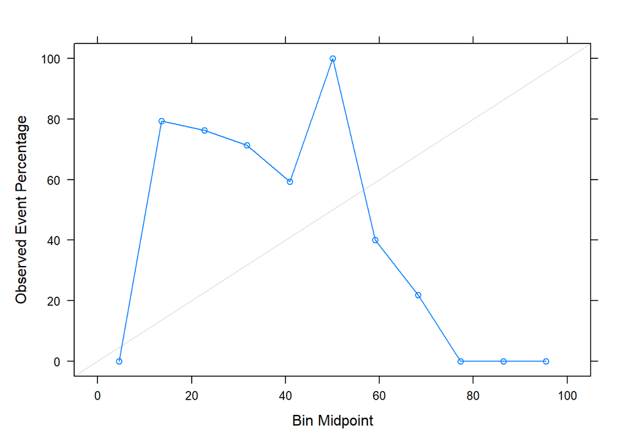

## Resampling techniques

### *k*-fold cross-validation

We next perform logistic regression using five repeats of 10-fold cross-validation, to generate 50 different holdout sets for estimating model accuracy. With *k* chosen to be 10, each training set contains 90% of the entire data set, while each test set contains the other 10% of the data.

```r
set.seed(1)

## Resampling specification is 5 repetitions of 10-fold cross-validation
# Make syntactically valid names for the factor levels of the response variable
logisticReg <- train(make.names(PONV0to24) ~ Age + Age^2 + Gender +
                       Diagnosis + Surgery + BMI +
                       Nonsmoker + KinetosisHistory + PONVhistory,
                     data = ponv,
                     method = "glm",
                     trControl = trainControl(method = "repeatedcv",
                                              number = 10,
                                              repeats = 5))

## Summary and results
logisticReg
```

```
## Generalized Linear Model
##
## 461 samples
##   8 predictor
##   2 classes: 'X0', 'X1'
##
## No pre-processing
## Resampling: Cross-Validated (10 fold, repeated 5 times)
## Summary of sample sizes: 416, 414, 415, 415, 414, 415, ...
## Resampling results:
##
##   Accuracy   Kappa
##   0.6380699  0.155806
```

```r
summary(logisticReg)
```

```
##
## Call:
## NULL
##
## Deviance Residuals:
##     Min       1Q   Median       3Q      Max
## -1.7753  -0.9663  -0.5579   1.1567   2.3369
##
## Coefficients:
##                     Estimate Std. Error z value Pr(>|z|)
## (Intercept)       -1.817e+01  1.171e+03  -0.016   0.9876
## Age               -3.662e-03  8.834e-03  -0.415   0.6785
## Gender1            8.547e-01  3.217e-01   2.656   0.0079 **
## Diagnosis1         9.179e-01  6.314e-01   1.454   0.1460
## Diagnosis2         1.079e+00  5.780e-01   1.868   0.0618 .
## Diagnosis3         1.081e+00  7.968e-01   1.357   0.1748
## Diagnosis4         1.108e+00  6.124e-01   1.809   0.0705 .
## Diagnosis5        -1.851e-01  8.955e-01  -0.207   0.8362
## Diagnosis6         1.136e+00  9.282e-01   1.224   0.2211
## Diagnosis7         1.493e+00  1.674e+00   0.892   0.3726
## Diagnosis8        -7.698e-01  1.217e+00  -0.632   0.5272
## Diagnosis9        -6.555e-01  1.450e+00  -0.452   0.6513
## Diagnosis10        1.634e+00  2.022e+00   0.808   0.4191
## Diagnosis11       -1.439e+01  2.400e+03  -0.006   0.9952
## Diagnosis12       -1.392e+01  1.696e+03  -0.008   0.9935
## Diagnosis13       -3.879e-02  8.915e-01  -0.044   0.9653
## Diagnosis14        1.801e+01  1.223e+03   0.015   0.9883
## Diagnosis15        6.021e-01  8.127e-01   0.741   0.4587
## Diagnosis16        7.782e-01  9.200e-01   0.846   0.3976
## Diagnosis17       -1.397e+01  1.340e+03  -0.010   0.9917
## Diagnosis18        1.664e+01  2.400e+03   0.007   0.9945
## Diagnosis19        5.787e-01  9.616e-01   0.602   0.5473
## Diagnosis20        8.271e-01  1.384e+00   0.598   0.5500
## Diagnosis23        1.838e+01  2.400e+03   0.008   0.9939
## Diagnosis24       -1.458e+01  2.400e+03  -0.006   0.9952
## Diagnosis25        1.896e+01  2.400e+03   0.008   0.9937
## Surgery1           1.530e+01  1.171e+03   0.013   0.9896
## Surgery2           1.522e+01  1.171e+03   0.013   0.9896
## Surgery3           3.240e+01  2.670e+03   0.012   0.9903
## Surgery4           1.548e+01  1.171e+03   0.013   0.9894
## Surgery5          -2.295e+00  1.693e+03  -0.001   0.9989
## Surgery7           1.426e+01  1.171e+03   0.012   0.9903
## BMI                2.241e-02  2.415e-02   0.928   0.3536
## Nonsmoker1         5.353e-01  2.454e-01   2.181   0.0292 *
## KinetosisHistory1  8.598e-02  4.972e-01   0.173   0.8627
## PONVhistory1       1.432e+00  3.414e-01   4.194 2.74e-05 ***
## ---
## Signif. codes:  0 '***' 0.001 '**' 0.01 '*' 0.05 '.' 0.1 ' ' 1
##
## (Dispersion parameter for binomial family taken to be 1)
##
##     Null deviance: 609.06  on 460  degrees of freedom
## Residual deviance: 522.95  on 425  degrees of freedom
## AIC: 594.95
##
## Number of Fisher Scoring iterations: 15
```

```r
## Confusion matrix
CM <- confusionMatrix(logisticReg); CM
```

```
## Cross-Validated (10 fold, repeated 5 times) Confusion Matrix
##
## (entries are percentual average cell counts across resamples)
##
##           Reference
## Prediction   X0   X1
##         X0 52.3 25.8
##         X1 10.4 11.5
##
##  Accuracy (average) : 0.6382
```

```r
## Sensitivity
print("Sensitivity:")
```

```
## [1] "Sensitivity:"
```

```r
CM$table[4]/(CM$table[3]+CM$table[4])
```

```
## [1] 0.3093023
```

```r
## Specificity
print("Specificity:")
```

```
## [1] "Specificity:"
```

```r
CM$table[1]/(CM$table[1]+CM$table[2])
```

```
## [1] 0.83391
```

```r
## ROC curve
YhatTestProb = predict(logisticReg, ponv, type = 'prob')
roc <- roc(as.factor(as.numeric(PONV0to24)-1),
         as.numeric(unlist(YhatTestProb[,2])))
roc$auc
```

```
## Area under the curve: 0.7358
```

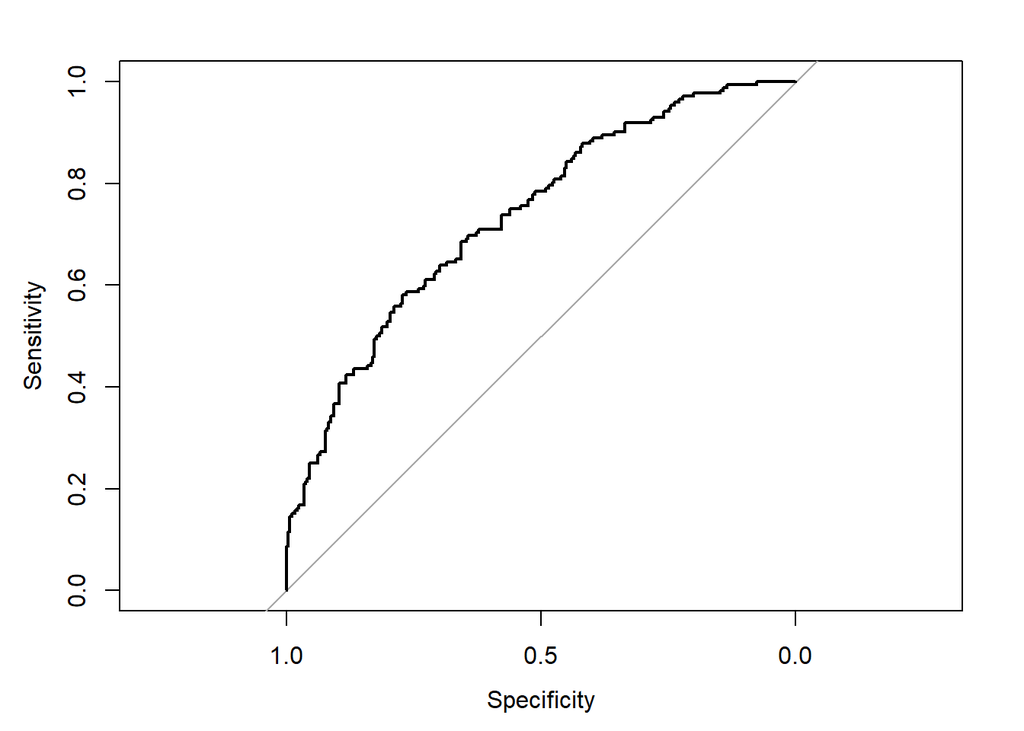

```r
plot(roc)
```

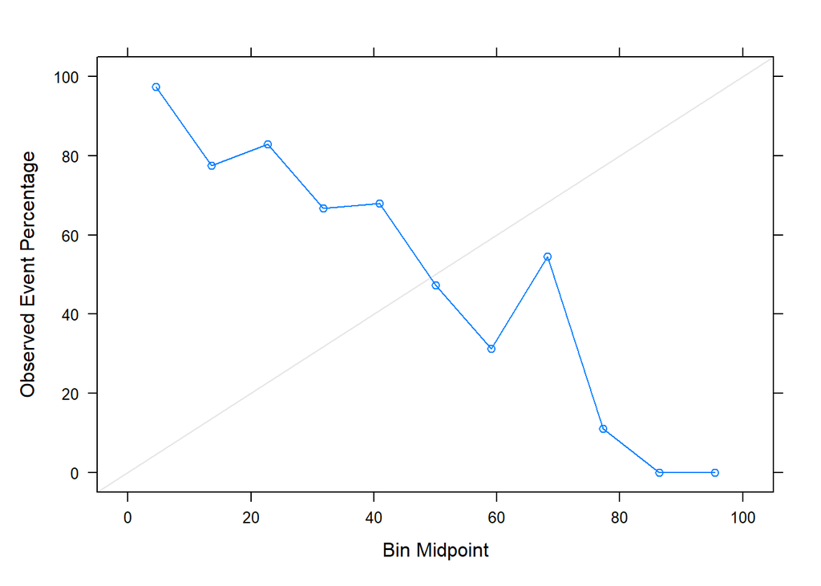

```r
## Calibration plot
calibProbs = calibration(as.factor(as.numeric(PONV0to24)-1) ~
                           as.numeric(unlist(YhatTestProb[,2])))
xyplot(calibProbs)
```

Repeated 10-fold cross-validation resulted in a logistic regression model with an AUC of 0.74, which is an improvement over the AUC of 0.64 obtained for our baseline model developed from all possible subets. With a sensitivity of 0.31 and a specificity of 0.83, the model is poor at classifying high risk patients, but good at classifying low risk patients.

The choice of *k* to be 10 for *k*-fold cross-validation avoids the high bias of smaller values of *k*, as well as the computational burden of higher values of *k*. *k*-fold cross-validation generally has high variance compared to other methods. The potential issues with bias and variance become negligible for large training sets. Applying 10-fold cross-validation to our data set resulted in training sets each having a sample size between 414 and 416, which may be considered reasonably large. Furthermore, repeating the *k*-fold cross-validation procedure is known as an effective way to increase the precision of the estimates and still maintain a small bias.

Three of the predictors in the full model have estimated coefficients that are statistically significant at the $\alpha=.05$ level or lower. In descending order of significance, these are PONV history, gender, and nonsmoker. These match the subset of predictors obtained from the model fitted using all possible subsets on the full data set.

We next look at the bootstrap technique of resampling.

### The bootstrap

A random sample equal to the size of the data set is taken *with replacement*. This is repeated 25 times to fit the full logistic regression model.

```r
bootStrap <- train(make.names(PONV0to24) ~ Age + I(Age^2) + Gender +
                     Diagnosis + Surgery + BMI +
                     Nonsmoker + KinetosisHistory + PONVhistory,
                   data = ponv,
                   method = "glm",
                   metric = "ROC",
                   trControl = trainControl(method = "boot",
                                            classProbs = TRUE))

## Summary and results
bootStrap # summary and results
```

```
## Generalized Linear Model
##
## 461 samples
##   8 predictor
##   2 classes: 'X0', 'X1'
##
## No pre-processing
## Resampling: Bootstrapped (25 reps)
## Summary of sample sizes: 461, 461, 461, 461, 461, 461, ...
## Resampling results:
##
##   Accuracy   Kappa
##   0.6293991  0.1629926
```

```r
summary(bootStrap) # coefficient estimates
```

```
##
## Call:
## NULL
##
## Deviance Residuals:
##     Min       1Q   Median       3Q      Max
## -1.8339  -0.9581  -0.5420   1.1239   2.3112
##
## Coefficients:
##                     Estimate Std. Error z value Pr(>|z|)
## (Intercept)       -1.994e+01  1.168e+03  -0.017   0.9864
## Age                7.853e-02  5.507e-02   1.426   0.1539
## `I(Age^2)`        -8.170e-04  5.392e-04  -1.515   0.1298
## Gender1            8.152e-01  3.223e-01   2.529   0.0114 *
## Diagnosis1         8.950e-01  6.322e-01   1.416   0.1569
## Diagnosis2         1.077e+00  5.786e-01   1.862   0.0627 .
## Diagnosis3         1.053e+00  7.991e-01   1.318   0.1875
## Diagnosis4         1.189e+00  6.157e-01   1.932   0.0534 .
## Diagnosis5        -1.127e-01  8.928e-01  -0.126   0.8996
## Diagnosis6         1.204e+00  9.253e-01   1.301   0.1933
## Diagnosis7         1.488e+00  1.688e+00   0.882   0.3780
## Diagnosis8        -8.362e-01  1.218e+00  -0.687   0.4924
## Diagnosis9        -8.259e-01  1.453e+00  -0.568   0.5697
## Diagnosis10        2.031e+00  2.040e+00   0.996   0.3193
## Diagnosis11       -1.348e+01  2.400e+03  -0.006   0.9955
## Diagnosis12       -1.376e+01  1.696e+03  -0.008   0.9935
## Diagnosis13       -4.460e-02  8.909e-01  -0.050   0.9601
## Diagnosis14        1.822e+01  1.220e+03   0.015   0.9881
## Diagnosis15        5.787e-01  8.139e-01   0.711   0.4771
## Diagnosis16        9.297e-01  9.279e-01   1.002   0.3164
## Diagnosis17       -1.398e+01  1.336e+03  -0.010   0.9916
## Diagnosis18        1.680e+01  2.400e+03   0.007   0.9944
## Diagnosis19        7.261e-01  9.649e-01   0.753   0.4517
## Diagnosis20        7.744e-01  1.380e+00   0.561   0.5746
## Diagnosis23        1.851e+01  2.400e+03   0.008   0.9938
## Diagnosis24       -1.479e+01  2.400e+03  -0.006   0.9951
## Diagnosis25        1.888e+01  2.400e+03   0.008   0.9937
## Surgery1           1.535e+01  1.168e+03   0.013   0.9895
## Surgery2           1.532e+01  1.168e+03   0.013   0.9895
## Surgery3           3.246e+01  2.669e+03   0.012   0.9903
## Surgery4           1.563e+01  1.168e+03   0.013   0.9893
## Surgery5          -2.504e+00  1.689e+03  -0.001   0.9988
## Surgery7           1.415e+01  1.168e+03   0.012   0.9903
## BMI                1.406e-02  2.485e-02   0.566   0.5716
## Nonsmoker1         5.910e-01  2.495e-01   2.368   0.0179 *
## KinetosisHistory1  1.241e-02  4.976e-01   0.025   0.9801
## PONVhistory1       1.409e+00  3.430e-01   4.106 4.02e-05 ***
## ---
## Signif. codes:  0 '***' 0.001 '**' 0.01 '*' 0.05 '.' 0.1 ' ' 1
##
## (Dispersion parameter for binomial family taken to be 1)
##
##     Null deviance: 609.06  on 460  degrees of freedom
## Residual deviance: 520.59  on 424  degrees of freedom
## AIC: 594.59
##
## Number of Fisher Scoring iterations: 15
```

```r
## Confusion matrix
CM <- confusionMatrix(bootStrap); CM
```

```
## Bootstrapped (25 reps) Confusion Matrix
##
## (entries are percentual average cell counts across resamples)
##
##           Reference
## Prediction   X0   X1
##         X0 49.2 23.7
##         X1 13.4 13.7
##
##  Accuracy (average) : 0.629
```

```r
## Sensitivity
print("Sensitivity:")
```

```
## [1] "Sensitivity:"
```

```r
CM$table[4]/(CM$table[3]+CM$table[4])
```

```
## [1] 0.3670246
```

```r
## Specificity
print("Specificity:")
```

```
## [1] "Specificity:"
```

```r
CM$table[1]/(CM$table[1]+CM$table[2])
```

```
## [1] 0.7854449
```

```r
## ROC curve
YhatTestProb = predict(bootStrap, ponv, type = 'prob')
roc <- roc(as.factor(as.numeric(PONV0to24)-1),
         as.numeric(unlist(YhatTestProb[,2])))
roc$auc
```

```
## Area under the curve: 0.7408
```

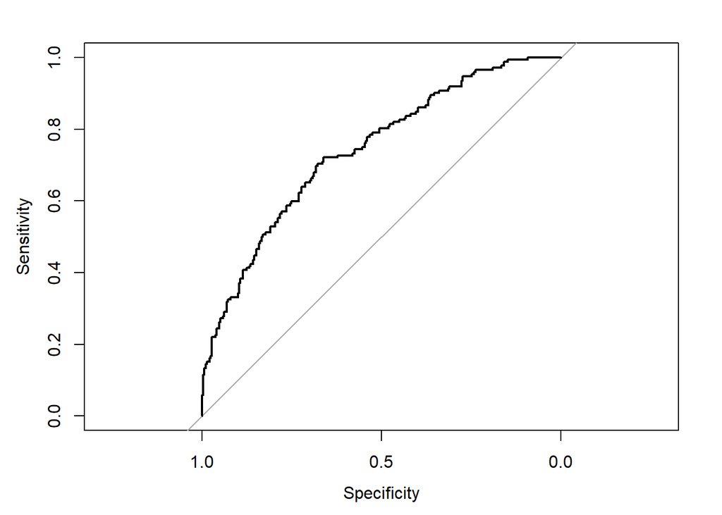

```r
plot(roc)
```

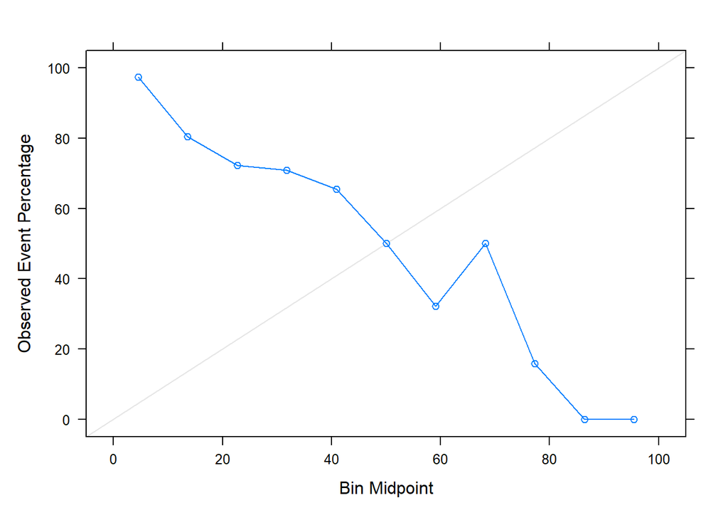

```r
## Calibration plot
calibProbs = calibration(as.factor(as.numeric(PONV0to24)-1) ~
                           as.numeric(unlist(YhatTestProb[,2])))
xyplot(calibProbs)
```

Three of the predictors in the full model have estimated coefficients that are statistically significant at the $\alpha=.05$ level or lower. In descending order of significance, these are PONV history, gender, and nonsmoker. These match the subset of predictors obtained from the preceding two models.

## Predictions

We will next make predictions of PONV for some examples of hypothetical patients. Our logistic regression model obtained from all possible subsets consists of three predictors which are all binary variables. Since it lacks the numerous dummy variables of the two models trained with resampling techniques, we choose it as the parsimonious model to make our predictions.

```r
mean(predict(glmFit4, data.frame(PONVhistory="1", Gender="1", Nonsmoker="1"),type="response"))
```

```
## [1] 0.7167777
```

```r
mean(predict(glmFit4, data.frame(PONVhistory="1", Gender="1", Nonsmoker="0"),type="response"))
```

```
## [1] 0.6110923
```

```r
mean(predict(glmFit4, data.frame(PONVhistory="1", Gender="0", Nonsmoker="1"),type="response"))
```

```
## [1] 0.5221021
```

```r
mean(predict(glmFit4, data.frame(PONVhistory="1", Gender="0", Nonsmoker="0"),type="response"))
```

```
## [1] 0.4041599
```

```r
mean(predict(glmFit4, data.frame(PONVhistory="0", Gender="1", Nonsmoker="1"),type="response"))
```

```
## [1] 0.407475
```

```r
mean(predict(glmFit4, data.frame(PONVhistory="0", Gender="1", Nonsmoker="0"),type="response"))
```

```
## [1] 0.2992145
```

```r
mean(predict(glmFit4, data.frame(PONVhistory="0", Gender="0", Nonsmoker="1"),type="response"))
```

```
## [1] 0.2289091
```

```r
mean(predict(glmFit4, data.frame(PONVhistory="0", Gender="0", Nonsmoker="0"),type="response"))
```

```
## [1] 0.15563
```

## References

Apfel, C. C., Kranke, P., Eberhart, L. H. J., Roos, A., and Roewer, N. (2002), “Comparison of Predictive Models for Postoperative Nausea and Vomiting,” *British Journal of Anaesthesia*, 88 (2), 234-40.

Eberhart, L. H. J., Hogel, J., Seeling, W., Staack, A.M., Geldner, G., and Georgieff, M. (2000), “Evaluation of Three Risk Scores to Predict Postoperative Nausea and Vomiting,” *Acta Anaesthesiologica Scandinavica*, 44, 480–488.

James, G., Witten, D., Hastie, T., and Tibshirani, R. (2021), *An Introduction to Statistical Learning* (2nd ed.), New York, NY: Springer Science+Business Media, LLC.

Kuhn, M., and Johnson, K. (2013), *Applied Predictive Modeling*, New York , NY: Springer Science+Business Media, LLC.

Pampel, F. C. (2021), *Logistic Regression* (2nd ed.), Thousand Oaks, CA: SAGE Publications, Inc.

Sheather, S. J. (2009), *A Modern Approach to Regression with R*, New York, NY: Springer Science+Business Media, LLC.

Sinclair, D. R., Chung, F., and Mezei, G. (1999), “Can Postoperative Nausea and Vomiting Be Predicted?” *Anesthesiology*, 91, 109-118.

Thomas, R., Jones, N. A., and Strike, P. (2002), “The Value of Risk Scores for Predicting Postoperative Nausea and Vomiting when Used to Compare Patient Groups in a Randomised Controlled Trial,” *Anaesthesia*, 57, 1119-1128.

van den Bosch, J.E., Kalkman, C. J., Vergouwe, Y., Van Klei, W. A., Bonsel, G. J., Grobbee, D. E., and Moons, K. G. M. (2005), “Assessing the Applicability of Scoring Systems for Predicting Postoperative Nausea and Vomiting,” *Anaesthesia*, 60, 323-331.

Vidakovic, B. (2017), *Engineering Biostatistics*, Hoboken, NJ: John Wiley & Sons Ltd.